# Sub_metering Analytics Project

Itoro_E

7/2/2019

This project centers around visualizations and time series analysis of sub-meters.

```r
# Load packages
#install.packages("RMySQL")
#install.packages("magrittr")
library(magrittr)
```

```r
library(RMySQL)
library(DBI)
#library(pacman)
library(Hmisc)      #for descriptive statistics
library(tidyverse)  #Package for tidying data
library(lubridate)  #For working with dates/times of a time series
library(VIM)        #Visualizing and imputing missing values
library(broom)      #Tidy statistical summary output
library(knitr)      #report generation
library(kableExtra) #fancy table generator
library(psych)
```

Create a database connection

```r
 con = dbConnect(MySQL(), user='deepAnalytics', password='Sqltask1234!',
                 dbname='dataanalytics2018', host='data-analytics-2018.cbrosir2cswx.us-east-1.rds.amazonaws.com')
```

Use RMySQL to connect to the database and see what it contains. List the tables contained in the database

```r
dbListTables(con)
```

```
## [1] "iris"    "yr_2006" "yr_2007" "yr_2008" "yr_2009" "yr_2010"
```

Lists attributes contained in a table

```r
dbListFields(con,'iris')
```

```
## [1] "id"            "SepalLengthCm" "SepalWidthCm"  "PetalLengthCm"
## [5] "PetalWidthCm"  "Species"
```

Use asterisk to specify all attributes for download

```r
irisALL <- dbGetQuery(con, "SELECT * FROM iris")
```

Use attribute names to specify specific attributes for download

```r
irisSELECT <- dbGetQuery(con, "SELECT SepalLengthCm, SepalWidthCm FROM iris")
```

Using the dbListFields function to learn the attributes associated with the yr_2006 table.

```r
#dbListFields(con, 'yr_2006')
```

Use the dbGetQuery function to download tables 2006 through 2010 with the specified attributes

```r
yr_2006ALL <- dbGetQuery(con, "SELECT * FROM yr_2006")
yr_2007ALL <- dbGetQuery(con, "SELECT * FROM yr_2007")
yr_2008ALL <- dbGetQuery(con, "SELECT * FROM yr_2008")
yr_2009ALL <- dbGetQuery(con, "SELECT * FROM yr_2009")
yr_2010ALL <- dbGetQuery(con, "SELECT * FROM yr_2010")
```

create a Multi-Year data frame to serve as the primary data frame for the project. using dplyr package function “bind_rows Combine tables or df (ONLY includes the df that span an entire year: 2007, 2008, 2009)

```r
newDF <- dplyr::bind_rows(yr_2007ALL, yr_2008ALL, yr_2009ALL)
```

```r
# describe(newDF)
# head(newDF)
# tail(newDF)
```

```r
# Summary statistics for newDF data features
# summary(newDF)
```

data munging newDF to create a ‘DateTime’ attribute Combining the ‘Date’ and ‘Time’ col within df

```r
# Combining the Date and Time columns with 'cbind' function in dplyr
newDF1 <-cbind(newDF,paste(newDF$Date,newDF$Time), stringsAsFactors=FALSE)
```

Header name for new attribute in the 11th column

```r
colnames(newDF1)[11] <-"DateTime"
```

Move the DateTime attribute within the dataset to make it first column

```r
newDF2 <- newDF1[,c(ncol(newDF1), 1:(ncol(newDF1)-1))]
```

Using “SELECT” function to DROP old “Date” and “Time” columns from newDF2

```r
newDF3 <- dplyr::select(newDF2, -c(Date,Time, id))
```

```r
# Confirm class of new DateTime feature is converted
# class(newDF3$DateTime)
```

Convert data type of new DateTime feature

```r
newDF3$DateTime <- as.POSIXct(newDF3$DateTime, "%Y/%m/%d %H:%M:%S")
attr(newDF3$DateTime, "tzone") <- "Europe/Paris"
```

```r
#str(newDF3)
```

```r
# Using range() function to understand the timeframe that’s covered by newDF2
# range(newDF3$DateTime)
```

Visualize and Look for any missing data in new df after 2006 and 2010 removed

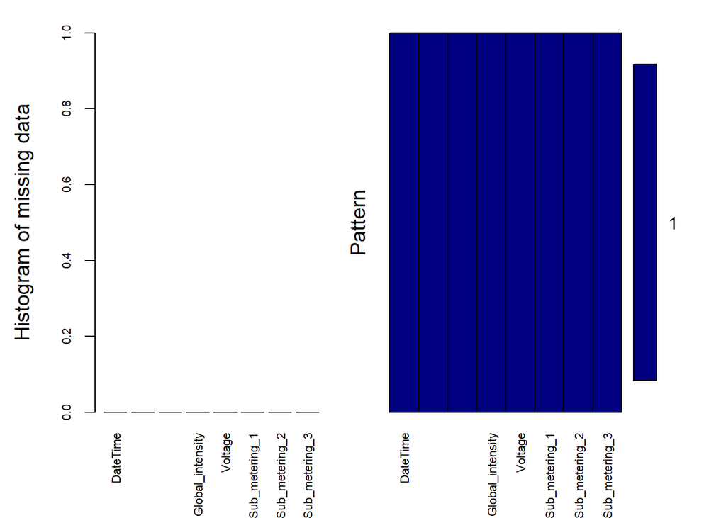

```
##
##  Variables sorted by number of missings:
##               Variable Count
##               DateTime     0
##    Global_active_power     0
##  Global_reactive_power     0
##       Global_intensity     0
##                Voltage     0
##         Sub_metering_1     0
##         Sub_metering_2     0
##         Sub_metering_3     0
```

```r
aggr(newDF3, col=c('navyblue','red'),
                  numbers=TRUE,
                  sortVars=TRUE,
                  labels=names(newDF3),
                  cex.axis=.7,
                  gap=3,
                  ylab=c("Histogram of missing data","Pattern"),
                  digits=2)
```

```r
newDF3$year <- year(newDF3$DateTime)
newDF3$quarter <- quarter(newDF3$DateTime)
newDF3$month <- month(newDF3$DateTime)
newDF3$week <- week(newDF3$DateTime)
newDF3$day <- day(newDF3$DateTime)
newDF3$hour <- hour(newDF3$DateTime)
newDF3$minute <- minute(newDF3$DateTime)
```

To aid with visualization of the three sub-meters data on the same chart new column ‘Sub_Meter’ which contains all three sub-meters is created. Another column ‘Watt_hr’ is created to store observed values for the sub-meters

```r
newDF_Data <- newDF3 %>%
  gather(Meter, Watt_hr, 'Sub_metering_1', 'Sub_metering_2', 'Sub_metering_3')
```

Converting ‘Meter’ feature to categorical factor

```r
newDF_Data$Meter <- factor(newDF_Data$Meter)
```

Use glimpse() to check on the Meter conversion before exploratory data analysis

```r
#glimpse(newDF_Data)
```

Data Exploration and Visualizations of Energy Usage Across a time periods in Sub-Meters

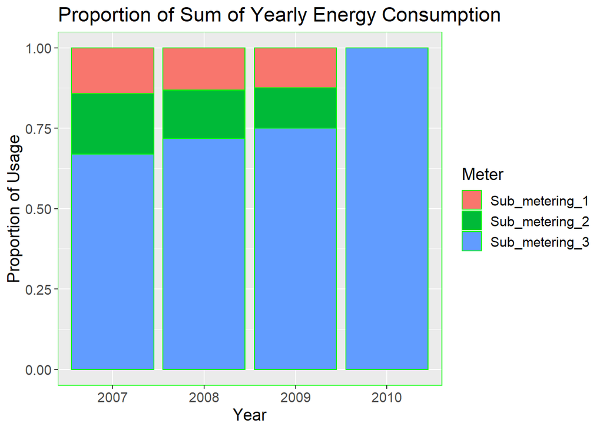

```r
#-Year_Proportional Plot
newDF_Data %>%
  group_by(year(DateTime), Meter) %>%
  summarise(sum=sum(Watt_hr)) %>%
  ggplot(aes(x=factor(`year(DateTime)`), sum, group=Meter,fill=Meter)) +
  labs(x='Year', y='Proportion of Usage') +
  ggtitle('Proportion of Sum of Yearly Energy Consumption') +
  geom_bar(stat='identity', position='fill', color='green') +
  theme(panel.border=element_rect(colour='green', fill=NA)) +
  theme(text = element_text(size = 14))
```

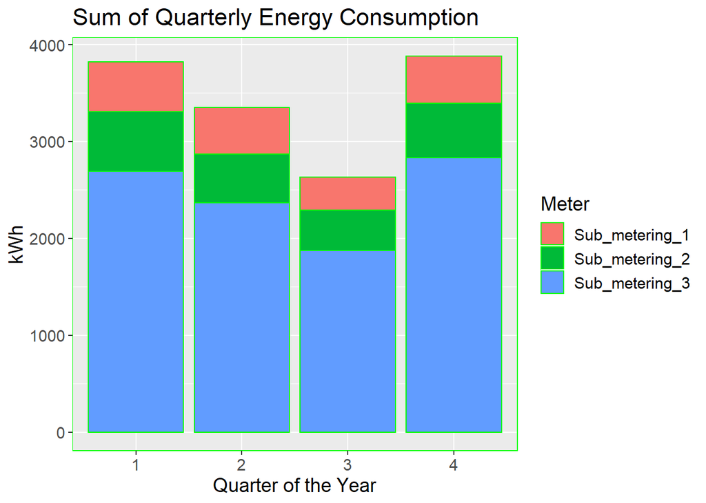

```r
# by_Quarterly bar plot
newDF_Data %>%
  filter(year(DateTime)<2010) %>%
  group_by(quarter(DateTime), Meter) %>%
  summarise(sum=round(sum(Watt_hr/1000),3)) %>%
  ggplot(aes(x=factor(`quarter(DateTime)`), y=sum)) +
  labs(x='Quarter of the Year', y='kWh') +
  ggtitle('Sum of Quarterly Energy Consumption') +
  geom_bar(stat='identity', aes(fill = Meter), color='green') +
  theme(panel.border=element_rect(colour='green', fill=NA)) +
  theme(text = element_text(size = 14))
```

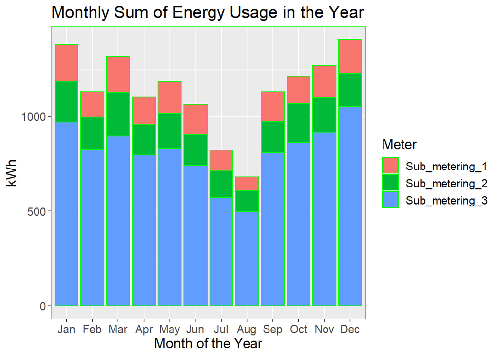

```r
# by_Month bar chart
newDF_Data %>%
  filter(year(DateTime)<2010) %>%
  mutate(Month=lubridate::month(DateTime, label=TRUE, abbr=TRUE)) %>%
  group_by(Month, Meter) %>%
  summarise(sum=round(sum(Watt_hr)/1000),3) %>%
  ggplot(aes(x=factor(Month), y=sum)) +
    labs(x='Month of the Year', y='kWh') +
    ggtitle('Monthly Sum of Energy Usage in the Year') +
    geom_bar(stat='identity', aes(fill = Meter), colour='green') +
  theme(panel.border=element_rect(colour='green', fill=NA)) +
  theme(text = element_text(size = 14))
```

Sampling the data by only the first quarter of 2007

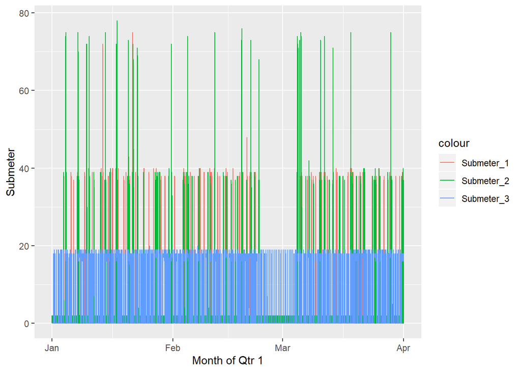

```r
# by_ Quarterly( Qtr 1 2007) line chart
Qtr1_2007 <- dplyr::filter(newDF3, year == 2007, quarter == 1)
  ggplot(Qtr1_2007, aes(DateTime)) +
    labs(x='Month of Qtr 1', y='Submeter') +
     geom_line(aes(y = Sub_metering_1, colour = "Submeter_1")) +
     geom_line(aes(y = Sub_metering_2, colour = "Submeter_2")) +
     geom_line(aes(y = Sub_metering_3, colour = "Submeter_3"))
```